### Code used to visualize relative growth rates of soil microbial assemblages and populations in multiple ecosystems.

#### 1. Load packages & data sets

- **Assemblage-level data**: A synthesis of published estimates of in-situ soil microbial growth rates at the assemblage level used to create Figure 2a. This data set is available in the SI (Supplementary Data 1) and on GitHub.
- **Population-level (qSIP) data**: A synthesis of published estimates of in-situ soil bacterial growth rates at the level of individual amplicon sequence variants. Data were obtained by H<sub>2</sub><sup>18</sup>O qSIP and used to create Figure 2b, c. Please contact Megan Foley (megan.foley@unil.ch) for data availability.

```r
library(ggplot2)
library(scales)
library(patchwork)
library(dplyr)
library(ggforce)
library(kableExtra)

assemblage.data = read.csv("~/desktop/Supplementary dataset 1.csv", header=TRUE, as.is= TRUE)
qsip.data = read.csv("~/desktop/qSIP database for Foley et al_final_for_Fig_1_for_public_redacted.csv", header=TRUE, as.is= TRUE) #email corresponding author for ASV level qSIP data (Megan Foley - mmf289@nau.edu)
```

#### 2. Minor formatting changes for assemblage level data

```r
#Minor formatting of assemblage level data
colnames(assemblage.data) = c("Secondary.Source", "Reference", "Paper",
                   "Observaton", "Method", "Incub.length.d", "Depth", "Slurry",
                   "Incub.temp.C", "Ecosystem", "RGR.per.day", "SD.RGR", "N")

assemblage.data$Method = factor(assemblage.data$Method, levels=c("H218O SIP with IRMS",
                                               "thymidine incorporation",
                                               "leucine incorporation",
                                               "LH-SIP",
                                               "qSIP",
                                               "soil C mass balance modeling",
                                               "direct cell counts"))
```

#### **3. Take a look at the data sets.**

Please note that some metadata for population-level estimates of growth, like site names, were replaced with placeholder names. If you need any additional context about the experimental metadata, please feel free to contact me directly.

```r
options(knitr.table.format = "html")
head(assemblage.data) %>% kbl(caption = "assemblage level estimates") %>% kable_styling()
```

assemblage level estimates

| Secondary.Source | Reference | Paper | Observaton | Method | Incub.length.d | Depth | Slurry | Incub.temp.C | Ecosystem | RGR.per.day | SD.RGR | N |
| --- | --- | --- | --- | --- | --- | --- | --- | --- | --- | --- | --- | --- |
| Caro et al. 2023 | Caro et al. 2023 | 1 | 1 | LH-SIP | 7 | surface | Y | 20 | forest | 0.0489105 | 0.0177764 | NA |
| Caro et al. 2023 | Caro et al. 2023 | 1 | 2 | LH-SIP | 7 | surface | Y | 20 | grassland | 0.0358478 | 0.0130288 | NA |
| Caro et al. 2023 | Caro et al. 2023 | 1 | 3 | LH-SIP | 7 | surface | Y | 20 | tundra | 0.0154361 | 0.0056102 | NA |
| Caro et al. 2023 | Blazewicz et al. 2014 | 2 | 4 | qSIP | 7 | surface | N | 23 | grassland | 0.0909100 | 0.0330411 | 3 |
|  | Chen et al. 2020 | 3 | 5 | H218O SIP with IRMS | 1 | surface | N | 25 | agriculture | 0.0064549 | 0.0003158 | 4 |
|  | Chen et al. 2020 | 3 | 6 | H218O SIP with IRMS | 1 | surface | N | 25 | agriculture | 0.0054885 | 0.0006389 | 4 |

```r
head(qsip.data) %>% kbl(caption = "population level estimates") %>% kable_styling()
```

population level estimates

| X | experiment | site | taxon_id | treatment | replicate | time | time_point | Kingdom | Phylum | eaf | eaf_corrected | eaf_max |
| --- | --- | --- | --- | --- | --- | --- | --- | --- | --- | --- | --- | --- |
| 1 | experiment 2 | Himalayas | 457dfd0e10db05012960738cb46e8986 | Treatment 1 | 1 | 10 | 6 | Bacteria | Acidobacteriota | 0.0938693 | 0.0657726 | 0.3174 |
| 2 | experiment 2 | Himalayas | 31ea80441a75f31c392caefd43c5cac9 | Treatment 1 | 1 | 10 | 6 | Bacteria | Acidobacteriota | 0.1847940 | 0.1566972 | 0.3174 |
| 3 | experiment 2 | Himalayas | 2e76aee139d3be204869beaa08b36955 | Treatment 1 | 1 | 10 | 6 | Bacteria | Acidobacteriota | 0.1914326 | 0.1633359 | 0.3174 |
| 4 | experiment 2 | Himalayas | 5a6307fc6edb306ba70e7fe0e4ea3764 | Treatment 1 | 1 | 10 | 6 | Bacteria | Armatimonadota | 0.2581163 | 0.2300196 | 0.3174 |
| 5 | experiment 2 | Himalayas | dd24a73906fc8170ac07a02e12a7b7c9 | Treatment 1 | 5 | 10 | 6 | Bacteria | Actinobacteriota | -0.0745505 | 0.0000000 | 0.3174 |
| 6 | experiment 2 | Himalayas | 8e44a9b08b6731e86c9fe29a1d322703 | Treatment 1 | 1 | 10 | 6 | Bacteria | Proteobacteria | 0.1748204 | 0.1467237 | 0.3174 |

#### 4. Compute relative growth rates for qsip data

qSIP computes the mass of <sup>18</sup>O from H<sub>2</sub><sup>18</sup>O incorporated into microbial DNA during DNA synthesis in units of excess atom fraction (EAF) <sup>18</sup>O. Here we apply a detection limit of 0.002 to our measurements of EAF <sup>18</sup>O and use these data to compute relative growth rates of amplicon sequence variants.

```r
#compute relative growth rates for qsip data
qsip.data[qsip.data$eaf_corrected < 0.002, "eaf_corrected"] <- 0 #set lower detection limit

qsip.data = qsip.data %>% group_by(experiment, site, time_point, treatment, replicate, taxon_id) %>%
  mutate(rgr = log(1/(1-eaf_corrected/eaf_max)) * 1/time) #compute growth rate
```

#### 5. Plot assemblage-level growth rates by ecosystem

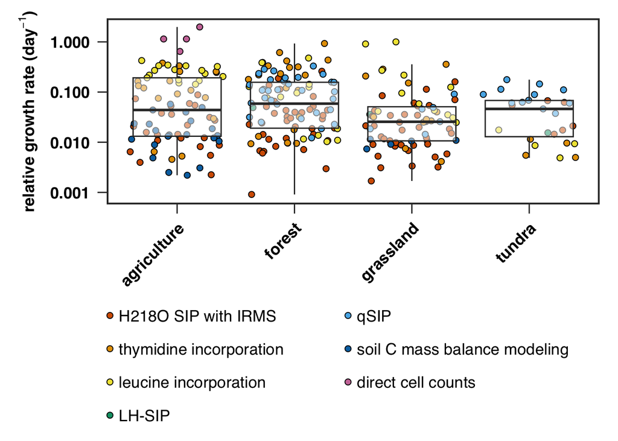

```r
nums= c(0.001, 0.01, 0.1, 1) #y-axis breaks
cols <- c("#D55E00", "#E69F00", "#F0E442", "#009E73", "#56B4E9", "#0072B2", "#CC79A7")

ggplot(assemblage.data, aes(x=Ecosystem, y=RGR.per.day)) +
  geom_point(aes(fill = Method),size=2, position = position_jitter(), pch = 21)+
  scale_y_continuous(trans = "log10",limits=c(0.00085,2), breaks = nums, label = label_number()) +
  geom_boxplot(outlier.shape = NA, alpha=0.5)+
  theme_bw(base_size=30) +
  labs(y=expression(bold(paste("relative growth rate (day",""^{-1}, ")")))) +
  scale_fill_manual(values = cols, name="method") +
  theme(legend.text = element_text(family = "helvetica", size=13, hjust = 0,margin = margin(r = 30, unit = "pt")),
        legend.position = "bottom",
        legend.spacing = unit(-10, "pt"),
        legend.key.height = unit(8, "pt"),
        legend.spacing.x = unit(1, "pt"),
        legend.key.width  = unit(15, "pt"),
        legend.margin=margin(t = 0, unit='cm'),
        legend.box.spacing = margin(15),
        legend.title = element_blank(),
        axis.title.x = element_blank(),
        axis.text.y = element_text(family = "helvetica",size=13, color = "black", face ="bold"),
        axis.title.y =element_text(family = "helvetica",size=13, color = "black", face ="bold"),
        axis.text.x = element_text(family = "helvetica",size=13, color = "black",angle = 45, vjust = 1, hjust=1, face ="bold"),
        panel.grid.minor=element_blank(),
        panel.grid.major=element_blank(),
        axis.ticks = element_line(size=0.5)) + guides(fill = guide_legend(ncol = 2))
```

#### 6. Plot distribution of population-level growth rates measured via qSIP

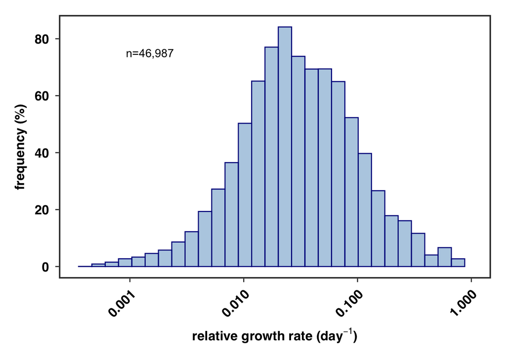

```r
numbers=c(.001, .01, .1, 1) #x-axis breaks

ggplot(qsip.data, aes(x = rgr)) +
  scale_x_continuous(trans = "log10", breaks=c(0, 0.001, 0.010, 0.100, 1), limits=c(NA,1)) +
  geom_histogram(aes(y = ..density..*(100)),color = "darkblue", fill="#1f77b460") +
  ylab("frequency (%)") +
  xlab(expression(bold(paste("relative growth rate (day",""^{-1}, ")")))) +
  theme_bw(base_size=30)+
  theme(plot.title = element_text(family = "helvetica",hjust = 0.5, size=17),
        axis.text.y = element_text(family = "helvetica",size=13, color = "black", face="bold"),
        axis.title.y = element_text(family = "helvetica",size=13, face="bold"),
        axis.text.x = element_text(family = "helvetica",size=13, color = "black", angle = 45, hjust=1, face="bold"),
        axis.title.x=element_text(family = "helvetica",size=13, face="bold"),
        panel.grid.minor=element_blank(),
        panel.grid.major=element_blank(),
        axis.ticks=element_line(size=0.5),
        axis.ticks.length=unit(0.05,"inch"),
        legend.background = element_rect(fill="transparent")) +
  annotate("text", x=0.0015, y=75, label= "n=46,987", size = 4)
```

#### 7. Plot distribution of population-level growth rates by phylum

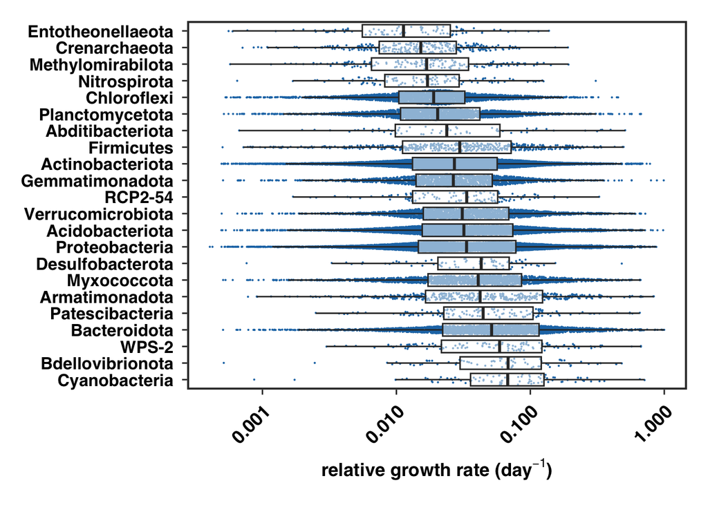

```r
qsip.data.2 <- qsip.data %>%
  dplyr::group_by(Phylum) %>%
  dplyr::filter(n() > 50)

ggplot(qsip.data.2, aes(y = reorder(qsip.data.2$Phylum,qsip.data.2$rgr, median), x = rgr)) +
  scale_x_continuous(trans = "log10", breaks=c(0, 0.001, 0.010, 0.100, 1), limits=c(NA,1)) +
  scale_y_discrete(limits = rev) +
  geom_sina(color="#1f77b4",size=0.05)+
  geom_boxplot(outlier.shape = NA, alpha=0.5) +
  theme_bw(base_size=30)+
  labs(x=expression(bold(paste("relative growth rate (day",""^{-1}, ")")))) +
  theme(plot.title = element_text(family = "helvetica",hjust = 0.75, size=17),
        axis.text.y = element_text(family = "helvetica",size=12, color = "black",  face="bold"),
        axis.text.x = element_text(family = "helvetica",size=13, color = "black", angle = 45, hjust=1, face="bold"),
        axis.title.x=element_text(family = "helvetica",size=13,  face="bold"),
        axis.title.y = element_blank(),
        axis.ticks.length=unit(0.05,"inch"),
        panel.grid.minor=element_blank(),
        panel.grid.major=element_blank(),
        axis.ticks=element_line(size=0.5),
        legend.background = element_rect(fill="transparent"),
        legend.position = "none")
```